# NON LINEAR REGRESSION MODELS

# Objective

This homework sheet will help reviewing the basic concepts associated with non-linear models. Please review the lectures, suggested readings, and additional resources *before* getting started on the HW.

**Some questions in this assignment will require you to conduct independent research beyond the material covered in the recorded content.**

**Some of the libraries / links mentioned in APPLIED questions are only for your reference. Unless specifically indicated, feel free to utilise any Python library of your choice to carry out the assignment questions**

PYGAM REFERENCE LINK:

https://pygam.readthedocs.io/en/latest/notebooks/tour_of_pygam.html

STATSMODELS REFERENCE LINK:

https://www.statsmodels.org/dev/glm.html

PATSY REFERENCE LINK:

https://patsy.readthedocs.io/en/latest/

The following website has access to the relevant datasets from the recommended textbook: https://book.huihoo.com/introduction-to-statistical-learning/data.html

Marks Distribution

| Question | Marks |
| --- | --- |
| 1a | 0.5 |
| 1b | 0.5 |
| 1c | 0.5 |
| 1d | 0.5 |
| 1e | 0.5 |
| 2 | 1 |
| 3 | 1 |
| 4 | 1 |
| 5a | 0.5 |
| 5b | 0.5 |
| 5c | 0.5 |
| 6a | 2 |
| 6b | 1 |
| 7a | 1 |
| 7b | 2 |
| 7c | 1 |
| 7d | 1 |

# Conceptual

## Question 1

Suppose that a curve $\hat{g}$ is computed to smoothly fit a set of `n` points using the following formula:

$$ \hat{g} = \arg\min_{g}(\sum_{i=1}^n (y_i - g(x_i))^2 + \lambda \int [g^{(m)} (x)]^2 dx ) $$ where $g^{(m)}$ represents the $m^{th}$ derivative of $g$ (and $g^{(0)} = g$. Provide a description (or sketch) of $\hat{g}$ in each of the following scenarios. where $g^{(m)}$ represents the m th derivative of g

(a) $\lambda$ = $\infty$, $m = 0$.

**ANSWER**

- When lambda is infinity, this means we only care about smoothness and do not care about fitting the data.
- When m = 0, this means that there will be no derivative penalty and we are penalizing the function itself (not its changes), meaning we are trying to make the function as small as possible.
- As lambda is infinity and m is zero, the function is forced to be completely smooth and shrink towards zero. The simplest and smoothest function that satisfies this is a flat line at zero.
- Hence, g(x) = 0 for all x
- This results in not fitting of the data at all.

**Explanation:**

In order to answer these questions and all the questions, it's important that we first understood the formula step by step.

1. The function above is trying to draw a smooth path through a set of data points.
2. It does this by balancing two things.  
   a. How well the curve fits the data, staying close to data points (Sum of Squared Error).  
   b. How smooth the curve is. We don't want the curve to deviate too much and try to fit the data exactly, ending as overfitting.

**Breaking Down:**

$(\sum_{i=1}^n (y_i - g(x_i))^2$ << The Data Fitting Term >>

1. This is a sum of squared errors between the given dat points $x_i, y_i$ and the function g(x):
2. This part measures how far our curve is from the actual data points.
3. If this value is small it means it means this curve passes very close to every point.
4. If this value is large it means this curve mises our data point by a lot.

$\lambda \int [g^{(m)} (x)]^2 dx$ << The Smoothness Penalty Term >>

1. This part adds a penalty to roughness.
2. The bigger this term is, the more the curve fluctuates.
3. The smaller this term is, the smoother the curve becomes.
4. $\lambda$ controls how much we care about smoothness (Weightage of Smoothness).
5. If $\lambda$ is large, we care about smoothness more than fitting the data.
6. If $\lambda$ is low we allow the curve to fit the data more closely (even if fluctuates alot).
7. $\arg\min_{g}$ means finds the function g(x) that minimize the total cost. It searches for the best balance.

**Terms Explanation:**

- $y_i$ is the actual observed value at $x_i$
- $g(x_i)$ is the predicted value from the function.
- The difference $y_i - g(x_i)$ measures how far the function is from the observed data.
- m represents the order of the derivative that we are penalizing.
- When m == 0, No derivative penalty and we penalize function itself.
- When m == 1, we penalize the first derivative (the slope).
- When m == 2, we penalize the second derivates (the curvature).
- When m == 3, we penalize the third derivatives (the rate of change of curvature).
- $\lambda$ repesents the smoothing.
- When $\lambda$ == 0, The penalty disappear.
- When $\lambda$ is small, the function follows data close with minor smoothing.
- When $\lambda$ is large, the function is forced to be smoother.
- When $\lambda$ is $\infty$, the function is completely smooth and ignores the data.
- Squaring ensures positive results and penalizing larger values more.
- argmin finds the input that gives the minimum value of the function.

**We will use this understanding to answer all the questions.**

(b) $\lambda$ = $\infty$, $m = 1$.

**ANSWER**

- When lambda is infinity, this means we only care about smoothness and do not care about fitting the data.
- When m == 1, this means we are penalizing the first derivative of the function, meaning we are trying to make the function as constant as possible (no rapid changes).
- As lambda = infinity, the function is forced to be completely smooth, meaning there should be no variation in slope. The simplest function that satisfies this is a horizontal straight line.
- Hence, g(x) = c, meaning the function is a flat constant line but not necessarily zero.
- This leads to underfitting because the function is too simple and does not capture any trends in the data.

(c) $\lambda$ = $\infty$, $m = 2$.

**ANSWER**

- When lambda is infinity, this means we only care about smoothness and do not care about fitting the data.
- When m = 2, this means we are penalizing the 2nd derivative of the function, meaning we are trying to make the function as linear as possible (no curvature).
- As lambda = infinity, the function is forced to be completely smooth, meaning there should be no variation in slope. The simplest function that satisfies this is a straight line equation.
- Hence, g(x)= ax + b, meaning the function is a straight line (A Linear Function). Hence this might results in underfitting as the function may not capture the true pattern in the data.

(d) $\lambda$ = $\infty$, $m = 3$.

**ANSWER**

- When lambda is infinity, this means we only care about smoothness and do not care about fitting the data.
- When m = 3, this means we are penalizing the 3rd derivative of the function, meaning we are trying to make the function as quadratic as possible (no sudden change in curvature).
- As lambda = infinity, the function is forced to be completely smooth, meaning there should be no variation in rate of curvature. The simplest function that satisfies this is a quadratic polynomial.
- Hence, g(x)= $ax^2 + bx + c, meaning the function is a parabolic (quadratic) function.

(e) $\lambda$ = 0, $m = 3$.

**ANSWER**

- When lambda = 0, this means the penalty term will disapear or we do not care about smoothness and only focus on fitting the data as closely as possible.
- When m = 3, this means the function is allowed to have any third derivative changes, meaning it can be highly flexible.
- As lambda = 0, the function is only trying to minimize the data fitting term. Which means it'll try to pass through all data points.
- Hence g(x) will be a highly flexible function that interpolate the data. This will result in overfitting as the function may capture noise instead of true pattern.

## Question 2

For (1) step functions, (2) local regression, and (3) GAMs: provide one situation when using that particular model is advantageous. For instance, “GAMs is likely the preferred option when the question I’m interested in addressing involves…”.

**ANSWER**

**Step Functions:** Step functions are best when changes happen at clear/fixed steps, not gradually. For example Ticket prices based on age groups, a step function is great here because the price does not change smoothly, but jumps at fixed points:

- Ages 0-5: Free
- Ages 6-12: $10
- Ages 13-60: $20
- Ages 60+: $15

**Local Regression:** Local regression is best when things change gradually and differently in different areas. For example House Prices along a coast line, a local regression is useful here because house prices usually rise and fall differently depending on the location. Using local regression here, it adjusts smoothly based on nearby data, capturing different trends in different areas.

- Inland house: More Affordable
- Coastal house: More Expensive
- Right next to the beach: Super Expensive

**GAMs (Generalize Additive Models):** GAMs are best when different factors affects the outcome in their own way. For example predicting happiness based on Sleep, Exercise and Stress levels. GAMs are useful here becuse they let each factor have it's own unique effect by combining them smoothly.

- Sleep: More sleep increase happiness, but too much may not help.
- Exercise: Regular exercise increases happiness, but too much may may end up in fatigue.
- Stress: High and continuous stress reduces happiness, but small challenges can be motivating.

## Question 3

Define the following types of smooth functions from PYGAM library (https://pygam.readthedocs.io/en/latest/notebooks/tour_of_pygam.html ) and list at least one relevant potential use:

a) l() linear terms

b) s() spline terms

c) f() factor terms

d) te() Tensor product interaction terms

**ANSWER**

**l() linear terms:**

Linear terms represent a straight-line relationship between two things. If one thing increases or decreases, the other does too, at a constant rate. For example fuel consumption in a car, the more distance you cover in KM the more fuel you burn at a constant rate.

`gam = LinearGAM(l('distance_covered'))`

**s() spline terms:**

Spline terms capture curves in data. Instead of a straight line, they let the relationship bend smoothly to fit patterns that aren’t constant. For example popularity of a cell phone after launch, sales increases after launch, peaks out at some point and then decline over time as new models comes out.

`gam = LinearGAM(s('time_since_launch'))`

**f() factor terms:**

Factor terms are used when we have categories instead of numbers. They allow us to see how each category affects the outcome individually. For example compare which airline gives the best services. Factor terms compare Emirates, Delta, Qatar etc offers different service quality. Factor terms let us compare them without assuming a numerical order.

`gam = LinearGAM(f('airline'))`

**te() tensor product interaction terms:**

Tensor product terms help when multiple things interact together in non-obvious/complex ways (not just one plus another but how they work together). For example how different workout types and durations affect muscle growth differently. For example combining Cardio, HIIT and Weight Trainings together effects muscle growth differently, these factors work together and too much and too less of 1 will have different impact, hence we can’t look at them separately of each other.

`gam = LinearGAM(te('cardio', 'hiit', 'weight_training'))`

## Question 4

Briefly explain what spatial and temporal autocorrelation are? List one way in which GAMs could help to account for this (e.g. indicate the type of smooth function you would use or potential types of correlation structures).

**ANSWER**

**Spatial autocorrelation** Autocorelation with respect to space occurs when nearby locations have similar values. Meaning that the data points close together tend to be more alike than those far apart. For example House prices in the same neighborhood tends to have similar prices because of share features like Schools, Parks and Crime Rate.

**Temporal autocorrelation** Autocorelation with respect to time occurs when data points collected close in time are similar. Meaning that the past values influence future values. For example, daily temperature trends. If temperature today is hot, it is likely to be hot tomorrow as well because temperature changes gradually over time.

**GAMs and its usage** GAMs (Generalized Additive Models) are a type of regression model that allows flexible, nonlinear relationships between predictors and the response variable. Instead of forcing a straight-line relationship like traditional regression, GAMs use smooth functions to model patterns in the data. GAMs are great when relationships between variables are nonlinear, and we want a model that smoothly adapts to patterns in the data without making strong assumptions.

- GAMs add together smooth functions for each predictor rather than assuming a strict linear relationship.
- These smooth functions (s(), te(), etc.) allow the model to adapt to complex trends without overfitting.

For **Spatial Autocorrelation,** like house price prediction depnding on location, we can use a bivariate spline s(latitude, logitude) to capture spatial patterns.

`gam = LinearGAM(s('latitude', 'longitude')) # Smooths house price trends by location`

For **Temporal Autocorrelation,** like Daily Temperature changes smoothly over time, we can use a univariate spline s(time) to smooth temperature fluctuations.

`gam = LinearGAM(s('time')) # Smooths temperature trends over time`

## Question 5

Consider two curves $\hat{g}1$ and $\hat{g}2$, defined by

$$ \hat{g}1 = \arg\min_{g}(\sum_{i=1}^n (y_i - g(x_i))^2 + \lambda \int [g^{(3)} (x)]^2 dx ) $$

$$ \hat{g}2 = \arg\min_{g}(\sum_{i=1}^n (y_i - g(x_i))^2 + \lambda \int [g^{(4)} (x)]^2 dx ) $$

where $g^{(m)}$ represents the $m^{th}$ derivative of $g$. Now, answer the following questions (and include a brief explanation):

a) As $\lambda \rightarrow \infty$, will $\hat{g}1$ or $\hat{g}2$ have smaller training RSS?

**ANSWER**

We have 2 curves g1 and g2. Each optimized with different smoothness penaltie:

- g1 penalizes the 3rd derivatives $g^{(3)}(x) = 0$. Meaning it's Quadratic ($g(x) = ax^2 + bx + c$) and explains curvature.
- g2 penalizes the 4th derivatives $g^{(4)}(x) = 0$. Meaning it's cubic ($g(x) = ax^3 + bx^2 + cx + d$) and explains rate of curvature.
- Both are subject to a smoothing penalty controlled by $\lambda$.
- As $(\lambda \rightarrow \infty)$, the penalty dominates, forcing the the functions to be only focus on smoothing and not concerned about fitting the data.
- Since $\hat{g}2$ is a cubic function, hence it is more flexible and can fit the training data better. Meaning the RSS would be smaller for g2 compared to g1 for training data.

b) As $\lambda \rightarrow \infty$, will $\hat{g}1$ or $\hat{g}2$ have smaller test RSS?

**ANSWER**

- Training RSS measures how well the model fits the training data.
- Test RSS measures how well the model generalizes to new, unseen data.

As $\lambda = \infty$

- The smoothness penalty dominates. Making the function overly simple.
- Too much smoothness can lead to underfitting, causing high test error.
- However higher complexity can increase test RSS as the model can capture unnecessary patterns or noise instead of actual trends.
- Since a quadratic function is simpler than a cubic function, it is less likely to retain noise.
- Hence, a quadratic function will generalize better to unseen data and will have a smaller test RSS.

c) For $\lambda= 0$, will $\hat{g}1$ or $\hat{g}2$ have smaller training RSS?

**ANSWER**

- When $\lambda = 0$, the penalty term disappears, and the function is optimized purely based on minimizing training RSS.
- More flexibility leads to a lower RSS because the model is free to fit the data as closely as possible.
- Since $\hat{g}^2$ (cubic function) is more flexibile than $\hat{g}1$ (quadratic function), it'll fit the training data better and have lower RSS.

APPLIED

## Question 6

This question relates to the `College` data set.

pre process the data if required

```python
! pip install pygam
```

```python
import numpy as np
import pandas as pd

from sklearn import preprocessing
from sklearn.preprocessing import StandardScaler
from sklearn.model_selection import train_test_split
from sklearn.metrics import mean_squared_error, r2_score, mean_absolute_error, mean_poisson_deviance

from pygam import GAM, LinearGAM, PoissonGAM, s, te

import matplotlib.pyplot as plt
from mpl_toolkits.mplot3d import Axes3D  # Import 3D plotting tools if needed
import seaborn as sns
```

```python
df_college = pd.read_csv('College.csv')
df_college.head()
```

|  | Unnamed: 0 | Private | Apps | Accept | Enroll | Top10perc | Top25perc | F.Undergrad | P.Undergrad | Outstate | Room.Board | Books | Personal | PhD | Terminal | S.F.Ratio | perc.alumni | Expend | Grad.Rate |
| --- | --- | --- | --- | --- | --- | --- | --- | --- | --- | --- | --- | --- | --- | --- | --- | --- | --- | --- | --- |
| 0 | Abilene Christian University | Yes | 1660 | 1232 | 721 | 23 | 52 | 2885 | 537 | 7440 | 3300 | 450 | 2200 | 70 | 78 | 18.1 | 12 | 7041 | 60 |
| 1 | Adelphi University | Yes | 2186 | 1924 | 512 | 16 | 29 | 2683 | 1227 | 12280 | 6450 | 750 | 1500 | 29 | 30 | 12.2 | 16 | 10527 | 56 |
| 2 | Adrian College | Yes | 1428 | 1097 | 336 | 22 | 50 | 1036 | 99 | 11250 | 3750 | 400 | 1165 | 53 | 66 | 12.9 | 30 | 8735 | 54 |
| 3 | Agnes Scott College | Yes | 417 | 349 | 137 | 60 | 89 | 510 | 63 | 12960 | 5450 | 450 | 875 | 92 | 97 | 7.7 | 37 | 19016 | 59 |
| 4 | Alaska Pacific University | Yes | 193 | 146 | 55 | 16 | 44 | 249 | 869 | 7560 | 4120 | 800 | 1500 | 76 | 72 | 11.9 | 2 | 10922 | 15 |

```python
df_college.info()
```

```
<class 'pandas.core.frame.DataFrame'>
RangeIndex: 777 entries, 0 to 776
Data columns (total 19 columns):
 #   Column       Non-Null Count  Dtype
---  ------       --------------  -----
 0   Unnamed: 0   777 non-null    object
 1   Private      777 non-null    object
 2   Apps         777 non-null    int64
 3   Accept       777 non-null    int64
 4   Enroll       777 non-null    int64
 5   Top10perc    777 non-null    int64
 6   Top25perc    777 non-null    int64
 7   F.Undergrad  777 non-null    int64
 8   P.Undergrad  777 non-null    int64
 9   Outstate     777 non-null    int64
 10  Room.Board   777 non-null    int64
 11  Books        777 non-null    int64
 12  Personal     777 non-null    int64
 13  PhD          777 non-null    int64
 14  Terminal     777 non-null    int64
 15  S.F.Ratio    777 non-null    float64
 16  perc.alumni  777 non-null    int64
 17  Expend       777 non-null    int64
 18  Grad.Rate    777 non-null    int64
dtypes: float64(1), int64(16), object(2)
memory usage: 115.5+ KB
```

```python
df_college.describe(include='all').T
```

|  | count | unique | top | freq | mean | std | min | 25% | 50% | 75% | max |
| --- | --- | --- | --- | --- | --- | --- | --- | --- | --- | --- | --- |
| Unnamed: 0 | 777 | 777 | Abilene Christian University | 1 | NaN | NaN | NaN | NaN | NaN | NaN | NaN |
| Private | 777 | 2 | Yes | 565 | NaN | NaN | NaN | NaN | NaN | NaN | NaN |
| Apps | 777.0 | NaN | NaN | NaN | 3001.638353 | 3870.201484 | 81.0 | 776.0 | 1558.0 | 3624.0 | 48094.0 |
| Accept | 777.0 | NaN | NaN | NaN | 2018.804376 | 2451.113971 | 72.0 | 604.0 | 1110.0 | 2424.0 | 26330.0 |
| Enroll | 777.0 | NaN | NaN | NaN | 779.972973 | 929.17619 | 35.0 | 242.0 | 434.0 | 902.0 | 6392.0 |
| Top10perc | 777.0 | NaN | NaN | NaN | 27.558559 | 17.640364 | 1.0 | 15.0 | 23.0 | 35.0 | 96.0 |
| Top25perc | 777.0 | NaN | NaN | NaN | 55.796654 | 19.804778 | 9.0 | 41.0 | 54.0 | 69.0 | 100.0 |
| F.Undergrad | 777.0 | NaN | NaN | NaN | 3699.907336 | 4850.420531 | 139.0 | 992.0 | 1707.0 | 4005.0 | 31643.0 |
| P.Undergrad | 777.0 | NaN | NaN | NaN | 855.298584 | 1522.431887 | 1.0 | 95.0 | 353.0 | 967.0 | 21836.0 |
| Outstate | 777.0 | NaN | NaN | NaN | 10440.669241 | 4023.016484 | 2340.0 | 7320.0 | 9990.0 | 12925.0 | 21700.0 |
| Room.Board | 777.0 | NaN | NaN | NaN | 4357.526384 | 1096.696416 | 1780.0 | 3597.0 | 4200.0 | 5050.0 | 8124.0 |
| Books | 777.0 | NaN | NaN | NaN | 549.380952 | 165.10536 | 96.0 | 470.0 | 500.0 | 600.0 | 2340.0 |
| Personal | 777.0 | NaN | NaN | NaN | 1340.642214 | 677.071454 | 250.0 | 850.0 | 1200.0 | 1700.0 | 6800.0 |
| PhD | 777.0 | NaN | NaN | NaN | 72.660232 | 16.328155 | 8.0 | 62.0 | 75.0 | 85.0 | 103.0 |
| Terminal | 777.0 | NaN | NaN | NaN | 79.702703 | 14.722359 | 24.0 | 71.0 | 82.0 | 92.0 | 100.0 |
| S.F.Ratio | 777.0 | NaN | NaN | NaN | 14.089704 | 3.958349 | 2.5 | 11.5 | 13.6 | 16.5 | 39.8 |
| perc.alumni | 777.0 | NaN | NaN | NaN | 22.743887 | 12.391801 | 0.0 | 13.0 | 21.0 | 31.0 | 64.0 |
| Expend | 777.0 | NaN | NaN | NaN | 9660.171171 | 5221.76844 | 3186.0 | 6751.0 | 8377.0 | 10830.0 | 56233.0 |
| Grad.Rate | 777.0 | NaN | NaN | NaN | 65.46332 | 17.17771 | 10.0 | 53.0 | 65.0 | 78.0 | 118.0 |

```python
df_college.isna().sum()
```

```
Unnamed: 0     0
Private        0
Apps           0
Accept         0
Enroll         0
Top10perc      0
Top25perc      0
F.Undergrad    0
P.Undergrad    0
Outstate       0
Room.Board     0
Books          0
Personal       0
PhD            0
Terminal       0
S.F.Ratio      0
perc.alumni    0
Expend         0
Grad.Rate      0
dtype: int64
```

```python
# Convert private column from yes, no to binary 1 or 0
if df_college['Private'].dtype == 'object':
    # Change the values in private column from category to no
    df_college['Private'] = df_college['Private'].map({'Yes': 1, 'No':0})
    #Convert Private column from object to numerical
    df_college['Private'] = df_college['Private'].astype('int64')

df_college.info()
```

```
<class 'pandas.core.frame.DataFrame'>
RangeIndex: 777 entries, 0 to 776
Data columns (total 19 columns):
 #   Column       Non-Null Count  Dtype
---  ------       --------------  -----
 0   Unnamed: 0   777 non-null    object
 1   Private      777 non-null    int64
 2   Apps         777 non-null    int64
 3   Accept       777 non-null    int64
 4   Enroll       777 non-null    int64
 5   Top10perc    777 non-null    int64
 6   Top25perc    777 non-null    int64
 7   F.Undergrad  777 non-null    int64
 8   P.Undergrad  777 non-null    int64
 9   Outstate     777 non-null    int64
 10  Room.Board   777 non-null    int64
 11  Books        777 non-null    int64
 12  Personal     777 non-null    int64
 13  PhD          777 non-null    int64
 14  Terminal     777 non-null    int64
 15  S.F.Ratio    777 non-null    float64
 16  perc.alumni  777 non-null    int64
 17  Expend       777 non-null    int64
 18  Grad.Rate    777 non-null    int64
dtypes: float64(1), int64(17), object(1)
memory usage: 115.5+ KB
```

```python
# if Unnamed: 0 column exists in df_college drops it
if 'Unnamed: 0' in df_college.columns:
    # We can drop this column.
    df_college.drop('Unnamed: 0', axis=1, inplace=True)

df_college.info()
```

```
<class 'pandas.core.frame.DataFrame'>
RangeIndex: 777 entries, 0 to 776
Data columns (total 18 columns):
 #   Column       Non-Null Count  Dtype
---  ------       --------------  -----
 0   Private      777 non-null    int64
 1   Apps         777 non-null    int64
 2   Accept       777 non-null    int64
 3   Enroll       777 non-null    int64
 4   Top10perc    777 non-null    int64
 5   Top25perc    777 non-null    int64
 6   F.Undergrad  777 non-null    int64
 7   P.Undergrad  777 non-null    int64
 8   Outstate     777 non-null    int64
 9   Room.Board   777 non-null    int64
 10  Books        777 non-null    int64
 11  Personal     777 non-null    int64
 12  PhD          777 non-null    int64
 13  Terminal     777 non-null    int64
 14  S.F.Ratio    777 non-null    float64
 15  perc.alumni  777 non-null    int64
 16  Expend       777 non-null    int64
 17  Grad.Rate    777 non-null    int64
dtypes: float64(1), int64(17)
memory usage: 109.4 KB
```

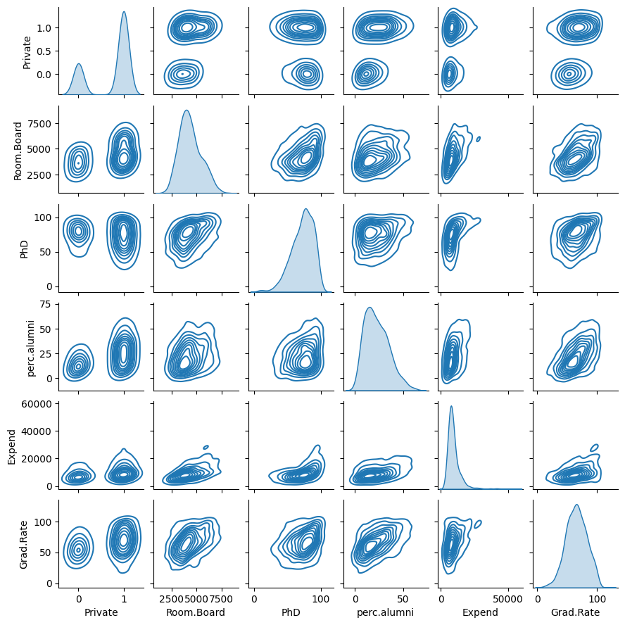

```python
predictor_cols = ['Private','Room.Board','PhD','perc.alumni', 'Expend' , 'Grad.Rate']

# Create a plot
sns.pairplot(data = df_college[predictor_cols], kind='kde', height=1.5)
plt.show()
```

a) Fit a GAM on the training data, using out-of-state tuition as the response and only subset of features as the predictors ( Select 'private', 'Room.Board' , 'PhD' , 'perc.alumni' , 'Expend' , 'Grad.rate' ) Plot the results and briefly explain your findings

**ANSWER**

```python
# # Since GAMs are sensitive to different scales, scaling numeric features helps ensure better performance
# # Scale the data
scaler = StandardScaler()
df_college_x_scaled = pd.DataFrame(scaler.fit_transform(df_college[predictor_cols]), columns=predictor_cols)

df_college_x_scaled.head()
```

|  | Private | Room.Board | PhD | perc.alumni | Expend | Grad.Rate |
| --- | --- | --- | --- | --- | --- | --- |
| 0 | 0.612553 | -0.964905 | -0.163028 | -0.867574 | -0.501910 | -0.318252 |
| 1 | 0.612553 | 1.909208 | -2.675646 | -0.544572 | 0.166110 | -0.551262 |
| 2 | 0.612553 | -0.554317 | -1.204845 | 0.585935 | -0.177290 | -0.667767 |
| 3 | 0.612553 | 0.996791 | 1.185206 | 1.151188 | 1.792851 | -0.376504 |
| 4 | 0.612553 | -0.216723 | 0.204672 | -1.675079 | 0.241803 | -2.939613 |

```python
df_college_x_scaled.info()
```

```
<class 'pandas.core.frame.DataFrame'>
RangeIndex: 777 entries, 0 to 776
Data columns (total 6 columns):
 #   Column       Non-Null Count  Dtype
---  ------       --------------  -----
 0   Private      777 non-null    float64
 1   Room.Board   777 non-null    float64
 2   PhD          777 non-null    float64
 3   perc.alumni  777 non-null    float64
 4   Expend       777 non-null    float64
 5   Grad.Rate    777 non-null    float64
dtypes: float64(6)
memory usage: 36.6 KB
```

```python
# Train test Split the data into training and test sets
X_train, X_test, y_train, y_test = train_test_split(
    df_college_x_scaled[predictor_cols],
    pd.DataFrame(df_college['Outstate'], columns=['Outstate']),
    test_size=0.2, random_state=1
)

X_train.shape, y_train.shape, X_test.shape, y_test.shape
```

```
((621, 6), (621, 1), (156, 6), (156, 1))
```

```python
X_train
```

|  | Private | Room.Board | PhD | perc.alumni | Expend | Grad.Rate |
| --- | --- | --- | --- | --- | --- | --- |
| 575 | 0.612553 | 1.498620 | 1.123923 | 2.039444 | 1.780779 | -0.259999 |
| 194 | 0.612553 | -0.828042 | -0.653295 | 0.666685 | -0.020729 | -0.726019 |
| 339 | 0.612553 | 2.000450 | 1.491623 | 0.101432 | 0.312515 | 0.264273 |
| 310 | 0.612553 | -0.326213 | 0.940072 | -0.221570 | -0.214849 | 0.031263 |
| 739 | -1.632512 | -1.338996 | -2.430512 | -1.029075 | -1.036939 | -0.318252 |
| ... | ... | ... | ... | ... | ... | ... |
| 715 | 0.612553 | 0.677445 | -0.163028 | -0.706073 | -0.355697 | 0.147768 |
| 767 | -1.632512 | -0.880962 | -0.101745 | 0.262933 | -0.561698 | -0.376504 |
| 72 | 0.612553 | 0.358099 | 1.369056 | 1.070438 | 0.769359 | 1.604080 |
| 235 | 0.612553 | -0.536069 | -0.530728 | 0.666685 | -0.327911 | -1.541554 |
| 37 | 0.612553 | 3.436593 | 0.633656 | 0.828186 | 0.559525 | 1.487575 |

621 rows × 6 columns

```python
# Define the GAM model with smooth terms for continuous variables
gam = LinearGAM(s(0) + s(1) + s(2) + s(3) + s(4) + s(5))
# Fit the GAM model
gam.fit(X_train, y_train)
```

```
LinearGAM(callbacks=[Deviance(), Diffs()], fit_intercept=True,
   max_iter=100, scale=None,
   terms=s(0) + s(1) + s(2) + s(3) + s(4) + s(5) + intercept,
   tol=0.0001, verbose=False)
```

```python
y_pred = gam.predict(X_test)
mse = mean_squared_error(y_test, y_pred)
mse
```

```
3847352.4484856604
```

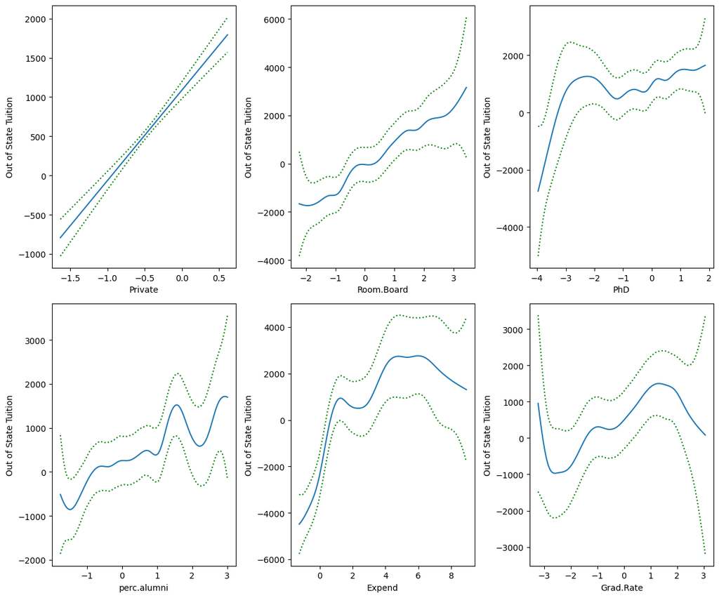

```python
# Plot the results
fig, axs = plt.subplots(2, 3, figsize=(12, 10))

for i, ax in enumerate(axs.flatten()):
    XX = gam.generate_X_grid(term=i)
    pdep, confi = gam.partial_dependence(term=i, X=XX, width=0.95)
    ax.plot(XX[:, i], pdep)
    ax.plot(XX[:, i], confi, c='g', ls=':')
    ax.set_ylabel('Out of State Tuition')
    ax.set_xlabel(predictor_cols[i])

plt.tight_layout()
plt.show()
```

## Interpretation

**Room & Board Costs**

- There is a positive, mostly linear correlation between out-of-state tuition and Room & Board costs.
- However, the confidence interval is wider than in the case of Private institutions, suggesting greater uncertainty in predictions.

**PhD Percentage**

- The relationship between out-of-state tuition and PhD percentage is nonlinear.
- Initially, tuition increases rapidly, followed by a slight decline, before rising again with a positive slope.
- This pattern suggests that the effect of PhD percentage varies across different ranges.

**Private Institution Status**

- Out-of-state tuition has a positive linear correlation with Private institutions.
- The confidence interval is very narrow, indicating low uncertainty in predictions.

**Percentage of Alumni**

- Out-of-state tuition has a nonlinear positive correlation with Percentage of Alumni.
- The slope increases at different rates across different predictor values.
- As the predictor value increases, uncertainty grows, leading to a wider confidence interval.

**Expenditures**

- The relationship between Expenditures and out-of-state tuition is nonlinear.
- Initially, the effect is strong, but after a certain point, the impact diminishes and starts to decline.
- Higher expenditures lead to greater uncertainty, as indicated by a wider confidence interval.

**Graduation Rate**

- The relationship between Graduation Rate and out-of-state tuition is irregular.
- The confidence interval is very wide, suggesting high uncertainty in predictions.
- The effect of graduation rate on tuition is unpredictable and inconsistent.

b) For which variables, if any, is there evidence of a non-linear relationship with the response?

ANSWER

The following variables exhibit a clear non-linear relationship with the response:

```
- PhD
- perc.alumni
- Expend
- Grad.Rate.
```

Meanwhile, Private demonstrates a strong linear relationship, while Room & Board appears to have a mostly linear but slightly variable relationship with the response.

## Question 7

Answer the questions below using the following dataset (WEEK3_Q7 CSV provided with the learner template):

a) Only by inspecting the plots shown below: Is there any temporal or spatial trend in the response variable `richness`?

```python
df_q7 = pd.read_csv('Week3_Q7.csv')
```

```python
df_q7.info()
```

```
<class 'pandas.core.frame.DataFrame'>
RangeIndex: 2824 entries, 0 to 2823
Data columns (total 9 columns):
 #   Column       Non-Null Count  Dtype
---  ------       --------------  -----
 0   Year         2824 non-null   int64
 1   Route        2824 non-null   int64
 2   statenum     2824 non-null   int64
 3   richness     2824 non-null   int64
 4   abundance    2824 non-null   int64
 5   Active       2824 non-null   int64
 6   Latitude     2824 non-null   float64
 7   Longitude    2824 non-null   float64
 8   RouteTypeID  2824 non-null   int64
dtypes: float64(2), int64(7)
memory usage: 198.7 KB
```

```python
df_q7.describe(include='all').T
```

|  | count | mean | std | min | 25% | 50% | 75% | max |
| --- | --- | --- | --- | --- | --- | --- | --- | --- |
| Year | 2824.0 | 1995.283286 | 13.169235 | 1966.000000 | 1987.000000 | 1997.000000 | 2006.000000 | 2015.000000 |
| Route | 2824.0 | 171.122167 | 303.107324 | 1.000000 | 19.000000 | 52.000000 | 87.000000 | 925.000000 |
| statenum | 2824.0 | 25.000000 | 0.000000 | 25.000000 | 25.000000 | 25.000000 | 25.000000 | 25.000000 |
| richness | 2824.0 | 47.113314 | 9.066053 | 19.000000 | 41.000000 | 47.000000 | 53.000000 | 79.000000 |
| abundance | 2824.0 | 689.820113 | 354.727766 | 147.000000 | 453.750000 | 615.000000 | 809.000000 | 4168.000000 |
| Active | 2824.0 | 0.830028 | 0.375674 | 0.000000 | 1.000000 | 1.000000 | 1.000000 | 1.000000 |
| Latitude | 2824.0 | 28.724434 | 1.659540 | 24.597703 | 27.426641 | 28.785686 | 30.292951 | 30.965694 |
| Longitude | 2824.0 | -82.661525 | 1.839859 | -87.407943 | -83.856968 | -82.118666 | -81.418950 | -80.203285 |
| RouteTypeID | 2824.0 | 1.000000 | 0.000000 | 1.000000 | 1.000000 | 1.000000 | 1.000000 | 1.000000 |

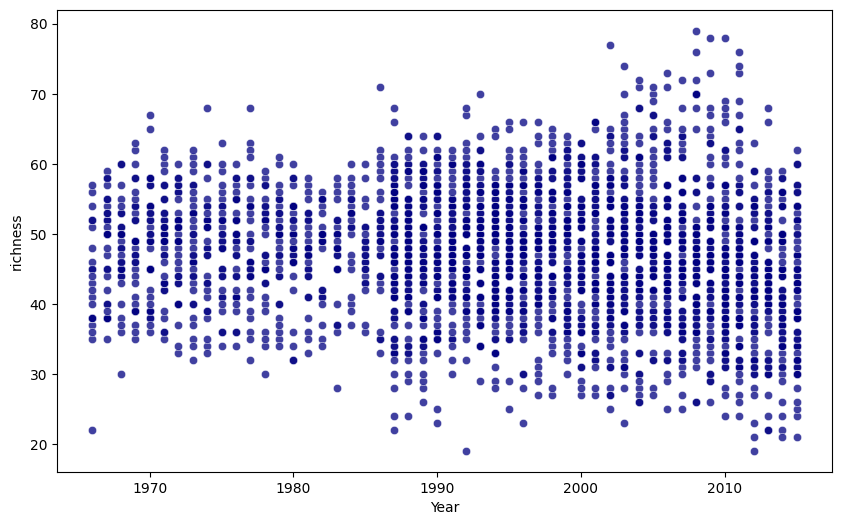

```python
# draw an scatter plot
plt.figure(figsize=(10,6))
sns.scatterplot(x = df_q7['Year'], y = df_q7['richness'], alpha=0.75, c='navy')
plt.show()
```

**ANSWER**  
The data exhibits a temporal trend, where richness fluctuates over different time periods. However, spatial trends cannot be analyzed using time series data alone. To examine spatial patterns, we would need spatial predictors that specify the location or geographic context of the data.

b) Now, fit a Poisson GAM with the following structure `E(richness) = exp(f(year))*exp(g(location))`. Note that location is actually two features: `Longitude` and `Latitude.` Name this model `M1.` Plot the model, get the `summary` of `M1`, and answer: Is there evidence for effects of location and year?

```python
Week_x = df_q7[['Year', 'Latitude', 'Longitude']]
Week_y = df_q7['richness']

Week_x_scaled =  preprocessing.scale(Week_x[['Year', 'Latitude', 'Longitude']])
Week_x_scaled = pd.DataFrame(Week_x_scaled, columns=['Year', 'Latitude', 'Longitude'])


# Train and Test split
X_train, X_test, y_train, y_test = train_test_split(
    Week_x_scaled, Week_y, test_size=0.2, random_state=1
)

# Fit the GAM model
M1 = PoissonGAM(s(0) + te(1, 2))
M1.fit(X = X_train, y = y_train)
```

```
PoissonGAM(callbacks=[Deviance(), Diffs()], fit_intercept=True,
   max_iter=100, terms=s(0) + te(1, 2) + intercept, tol=0.0001,
   verbose=False)
```

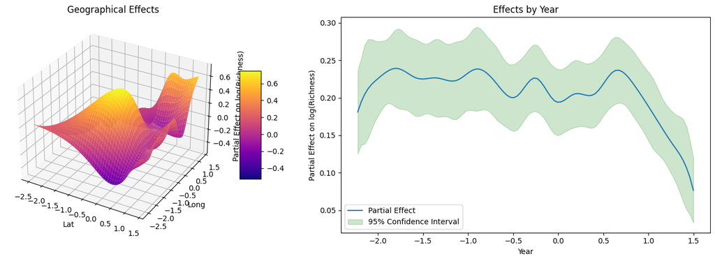

```python
# Create figure with 2D and 3D subplots (flipping their positions)
fig = plt.figure(figsize=(15, 5))

ax1 = fig.add_subplot(1, 2, 1, projection='3d')  # 3D plot for Location effect (Left)
ax2 = fig.add_subplot(1, 2, 2)  # 2D plot for Year effect (Right)

# 3D Partial Dependence for Location (Latitude & Longitude)
XX = M1.generate_X_grid(term=1, meshgrid=True)
Z = M1.partial_dependence(term=1, X=XX, meshgrid=True)

# Ensure correct shape for 3D plotting
lat, lon = XX
Z = Z.reshape(lat.shape)

# Create the 3D surface plot
surf = ax1.plot_surface(lat, lon, Z, cmap='plasma')

ax1.set_title('Geographical Effects')
ax1.set_xlabel('Lat')
ax1.set_ylabel('Long')
ax1.set_zlabel('Partial Effect on log(Richness)')

# 2D Partial Dependence for Year
XX_year = M1.generate_X_grid(term=0)
pdep, confi = M1.partial_dependence(term=0, X=XX_year, width=0.95)

ax2.plot(XX_year[:, 0], pdep, label="Partial Effect")
ax2.fill_between(XX_year[:, 0], confi[:, 0], confi[:, 1], color='g', alpha=0.2, label="95% Confidence Interval")

ax2.set_title('Effects by Year')
ax2.set_xlabel('Year')
ax2.set_ylabel('Partial Effect on log(Richness)')
ax2.legend()

# Add a color bar for better visualization
fig.colorbar(surf, ax=ax1, shrink=0.5, aspect=5)  # Updated to match the swapped axes

plt.tight_layout()
plt.show()
```

```python
# Print model summary
print(M1.summary())
```

```
PoissonGAM
=============================================== ==========================================================
Distribution:                       PoissonDist Effective DoF:                                     53.0194
Link Function:                          LogLink Log Likelihood:                                 -7481.0463
Number of Samples:                         2259 AIC:                                            15068.1314
                                                AICc:                                           15070.8284
                                                UBRE:                                               3.0155
                                                Scale:                                                 1.0
                                                Pseudo R-Squared:                                   0.4621
==========================================================================================================
Feature Function                  Lambda               Rank         EDoF         P > x        Sig. Code
================================= ==================== ============ ============ ============ ============
s(0)                              [0.6]                20           19.6         0.00e+00     ***
te(1, 2)                          [0.6 0.6]            100          33.4         0.00e+00     ***
intercept                                              1            0.0          0.00e+00     ***
==========================================================================================================
Significance codes:  0 '***' 0.001 '**' 0.01 '*' 0.05 '.' 0.1 ' ' 1

WARNING: Fitting splines and a linear function to a feature introduces a model identifiability problem
         which can cause p-values to appear significant when they are not.

WARNING: p-values calculated in this manner behave correctly for un-penalized models or models with
         known smoothing parameters, but when smoothing parameters have been estimated, the p-values
         are typically lower than they should be, meaning that the tests reject the null too readily.
None
```

```python
print(f"M1 Score on the training data = ",M1.score(X_train, y_train))
print(f"M1 Score on the test data = ",M1.score(X_test, y_test))
```

```
M1 Score on the training data =  0.4621430124922483
M1 Score on the test data =  0.47243557828087546
```

**ANSWER**

The scores reveal that the model accounts for approximately 47% of the deviance in both the training and test datasets. This suggests that:

- The model has successfully identified some meaningful patterns in the data.
- However, a significant portion of variation remains unexplained.
- The model generalizes well to unseen data, as the performance is consistent across both training and test sets.
- Both feature functions—s(0) for Year and te(1, 2) for Location—are highly significant (p-value < 0.001), as indicated by the '***' significance code.

c) Now, fit another Poisson GAM model with the same structure as in `M1` , name this model `M2` but using interactions between Year, Latitude and Longitude

```python
M2 = PoissonGAM(te(0, 1, 2, n_splines=[10, 10, 10]))
M2.fit(X = X_train, y = y_train)
# Print model summary
print(M2.summary())
```

```
PoissonGAM
=============================================== ==========================================================
Distribution:                       PoissonDist Effective DoF:                                      138.63
Link Function:                          LogLink Log Likelihood:                                 -7279.8103
Number of Samples:                         2259 AIC:                                            14836.8805
                                                AICc:                                           14855.4195
                                                UBRE:                                               2.9435
                                                Scale:                                                 1.0
                                                Pseudo R-Squared:                                    0.563
==========================================================================================================
Feature Function                  Lambda               Rank         EDoF         P > x        Sig. Code
================================= ==================== ============ ============ ============ ============
te(0, 1, 2)                       [0.6 0.6 0.6]        1000         138.6        0.00e+00     ***
intercept                                              1            0.0          0.00e+00     ***
==========================================================================================================
Significance codes:  0 '***' 0.001 '**' 0.01 '*' 0.05 '.' 0.1 ' ' 1

WARNING: Fitting splines and a linear function to a feature introduces a model identifiability problem
         which can cause p-values to appear significant when they are not.

WARNING: p-values calculated in this manner behave correctly for un-penalized models or models with
         known smoothing parameters, but when smoothing parameters have been estimated, the p-values
         are typically lower than they should be, meaning that the tests reject the null too readily.
None
```

```python
print("M2 Score on the training data = ", M2.score(X_train, y_train))
print("M2 Score on the test data = ", M2.score(X_test, y_test))
```

```
M2 Score on the training data =  0.5630332721701854
M2 Score on the test data =  0.5416641069719214
```

```python
# Compute test error metrics for M1
m1_pred = M1.predict(X_test[['Year', 'Latitude', 'Longitude']])
m1_mse = mean_squared_error(y_test, m1_pred)
m1_rmse = np.sqrt(m1_mse)
m1_dev = mean_poisson_deviance(y_test, m1_pred)

# Compute test error metrics for M2
m2_pred = M2.predict(X_test[['Year', 'Latitude', 'Longitude']])
m2_mse = mean_squared_error(y_test, m2_pred)
m2_rmse = np.sqrt(m2_mse)
m2_dev = mean_poisson_deviance(y_test, m2_pred)

# Print results with better formatting
print("\nTest Error Metrics Comparison:\n")
print(f"{'Metric':<20}{'M1':<15}{'M2'}")
print("-" * 50)
print(f"{'MSE':<20}{m1_mse:.4f}{'':<5}{m2_mse:.4f}")
print(f"{'RMSE':<20}{m1_rmse:.4f}{'':<5}{m2_rmse:.4f}")
print(f"{'Poisson Deviance':<20}{m1_dev:.4f}{'':<5}{m2_dev:.4f}")
```

```
Test Error Metrics Comparison:

Metric              M1             M2
--------------------------------------------------
MSE                 45.8513     39.2599
RMSE                6.7714     6.2658
Poisson Deviance    0.9794     0.8508
```

**ANSWER**

d) Compare `M1` and `M2`. Note that you can use the $R^2$, AIC values, test error, among other approaches discussed in class. Which model should we select?

**ANSWER**

**Model Complexity & Flexibility**

Effective Degrees of Freedom (EDoF): M2 has 138.63, which is significantly higher than M1 (53.0194). This suggests that M2 is a more complex model, allowing for greater flexibility in capturing patterns.

**Model Fit & Deviance Explained**

Pseudo R-Squared: M2 achieves 0.563, a clear improvement over M1 (0.4621). This indicates that M2 explains more deviance in the data, meaning it better captures the underlying patterns.

Log Likelihood: M2 has a higher (less negative) log-likelihood at -7279.8103, compared to M1 (-7481.0463), further suggesting a better fit.

**Conclusion:**

M2 demonstrates better model fit and explains more variation than M1, while maintaining an acceptable complexity level. However, its higher degrees of freedom suggest a more flexible, but potentially more sensitive, model.